# Principal Component Analysis with Cancer Data

# Q8 Find variance and cumulative variance by each eigen vector

```python
total=sum(val)
var_exp=[(i/total)*100 for i in sorted(val,reverse=True)]
```

```python
var_exp
```

```
[70.35044500693193,
 6.812073160553886,
 6.063861639917854,
 4.764921940252198,
 3.8227989952020662,
 3.7613310526649646,
 3.2956491505097265,
 1.1289190539673628]
```

```python
cum_var=np.cumsum(var_exp)
```

```python
cum_var
```

```
array([ 70.35044501,  77.16251817,  83.22637981,  87.99130175,
        91.81410074,  95.5754318 ,  98.87108095, 100.        ])
```

# Q9 Use PCA command from sklearn and find Principal Components. Transform data to components formed

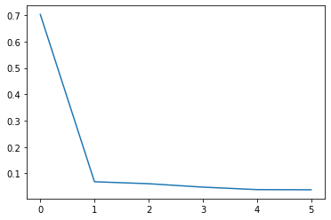

```python
from sklearn.decomposition import PCA
pca=PCA(n_components=6)
pca.fit_transform(df_scaled)
plt.plot(pca.explained_variance_ratio_)
```

```python
pca.components_
```

```
array([[ 0.31079981,  0.39099457,  0.38788497,  0.34266491,  0.34133551,
         0.34443292,  0.35895958,  0.34446593],
       [-0.86955194,  0.05259569, -0.01483394,  0.32890839,  0.25769789,
        -0.14150528,  0.11230247,  0.18348993],
       [ 0.10170908,  0.16540906,  0.13766573, -0.49706996,  0.41934802,
        -0.58510057, -0.15605866,  0.39206501],
       [ 0.05124955,  0.06038713,  0.01707264,  0.11853591,  0.66815453,
         0.09830051, -0.38181888, -0.61441478],
       [-0.23286625,  0.07992511,  0.08374641, -0.63151988,  0.12017881,
         0.24624939,  0.59190412, -0.3288195 ],
       [ 0.12413532,  0.26830258,  0.18115591,  0.29485424, -0.1984532 ,
        -0.64918334,  0.36361893, -0.44699691]])
```

```python
pca.explained_variance_ratio_
```

```
array([0.70350445, 0.06812073, 0.06063862, 0.04764922, 0.03822799,
       0.03761331])
```

# Q10 Find correlation between components and features

```python
comp=pd.DataFrame(data=pca.components_,columns=X.columns)
```

```python
comp
```

|  | ClumpThickness | Cell Size | Cell Shape | Marginal Adhesion | Single Epithelial Cell Size | Bare Nuclei | Normal Nucleoli | Bland Chromatin |
| --- | --- | --- | --- | --- | --- | --- | --- | --- |
| 0 | 0.310800 | 0.390995 | 0.387885 | 0.342665 | 0.341336 | 0.344433 | 0.358960 | 0.344466 |
| 1 | -0.869552 | 0.052596 | -0.014834 | 0.328908 | 0.257698 | -0.141505 | 0.112302 | 0.183490 |
| 2 | 0.101709 | 0.165409 | 0.137666 | -0.497070 | 0.419348 | -0.585101 | -0.156059 | 0.392065 |
| 3 | 0.051250 | 0.060387 | 0.017073 | 0.118536 | 0.668155 | 0.098301 | -0.381819 | -0.614415 |
| 4 | -0.232866 | 0.079925 | 0.083746 | -0.631520 | 0.120179 | 0.246249 | 0.591904 | -0.328820 |
| 5 | 0.124135 | 0.268303 | 0.181156 | 0.294854 | -0.198453 | -0.649183 | 0.363619 | -0.446997 |

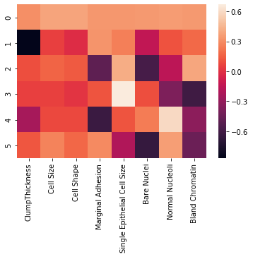

```python
sns.heatmap(comp)
```

# Popularity Based Recommendation System

### About Dataset

Anonymous Ratings on jokes.

1. Ratings are real values ranging from -10.00 to +10.00 (the value "99" corresponds to "null" = "not rated").
2. One row per user
3. The first column gives the number of jokes rated by that user. The next 100 columns give the ratings for jokes 01 - 100.